# Evaluación de calidad de carros

## Proyecto 2 – Modelos de clasificación supervisada para evaluar la calidad de un automovil

## Problema a resolver

Durante el proceso de decisión, un comprador evalúa múltiples atributos o variables que influyen en su percepción del producto. En el caso de un vehículo, la opinión del consumidor se forma a partir de diversos atributos, los cuales suelen estructurarse en una jerarquía que refleja el peso relativo de cada uno en la decisión de compra.

El presente estudio tiene un objetivo dual. En primer lugar, busca identificar y explicar las variables más significativas en la formación de una opinión favorable hacia un vehículo, proporcionando información valiosa para el negocio. En segundo lugar, pretende desarrollar un sistema experto capaz de predecir la opinión potencial del comprador basándose en características tangibles y operativas del vehículo. Este sistema contribuirá a anticipar la percepción del consumidor y optimizar el diseño de estrategias de marketing y producto.

El data set, es una combinación de diferentes variables creando un diseño factorial completo de seis variables independientes que pueden influir la opinión global de un automovil. Es un data set construido de forma experimental.

```python
!pip install ucimlrepo
```

```
  Obtaining dependency information for ucimlrepo from https://files.pythonhosted.org/packages/3b/07/1252560194df2b4fad1cb3c46081b948331c63eb1bb0b97620d508d12a53/ucimlrepo-0.0.7-py3-none-any.whl.metadata
Downloading ucimlrepo-0.0.7-py3-none-any.whl (8.0 kB)
```

```python
from ucimlrepo import fetch_ucirepo

# fetch dataset
car_evaluation = fetch_ucirepo(id=19)

# data (as pandas dataframes)
X = car_evaluation.data.features
y = car_evaluation.data.targets

# metadata
print(car_evaluation.metadata)

# variable information
print(car_evaluation.variables)

print(car_evaluation.columns)
```

```
{'uci_id': 19, 'name': 'Car Evaluation', 'repository_url': 'https://archive.ics.uci.edu/dataset/19/car+evaluation', 'data_url': 'https://archive.ics.uci.edu/static/public/19/data.csv', 'abstract': 'Derived from simple hierarchical decision model, this database may be useful for testing constructive …
       name     role         type demographic  \
0    buying  Feature  Categorical        None
1     maint  Feature  Categorical        None
2     doors  Feature  Categorical        None
3   persons  Feature  Categorical        None
4  lug_boot  Feature  Categorical        None
5    safety  Feature  Categorical        None
6     class   Target  Categorical        None

                                         description units missing_values
0                                       buying price  None             no
1                           price of the maintenance  None             no
2                                    number of doors  None             no
3              capacity in terms of persons to carry  None             no
4                           the size of luggage boot  None             no
5                        estimated safety of the car  None             no
6  evaulation level (unacceptable, acceptable, go...  None             no
None
```

```python
import pandas as pd

# Ruta al archivo .data
data_path = '/Users/ccs/Documents/UNIVERSIDAD/Especialización en Machine Learning/Machine Learning 1/Guía 1/Machine-learning1/car.data'

# Lista de nombres de columnas (según el archivo .names)
column_names = ['buying', 'maint', 'doors', 'persons', 'lug_boot', 'safety', 'class']  # Ajusta estos nombres de acuerdo al .names

# Cargar el archivo .data
car_evaluation = pd.read_csv(data_path, header=None, names=column_names)

# Ruta al archivo .names
names_path = '/Users/ccs/Documents/UNIVERSIDAD/Especialización en Machine Learning/Machine Learning 1/Guía 1/Machine-learning1/car.names'

# Leer y mostrar el contenido del archivo .names
with open(names_path, 'r') as f:
    names_content = f.read()

print(names_content)
```

```
1. Title: Car Evaluation Database

2. Sources:
   (a) Creator: Marko Bohanec
   (b) Donors: Marko Bohanec   (marko.bohanec@ijs.si)
               Blaz Zupan      (blaz.zupan@ijs.si)
   (c) Date: June, 1997

3. Past Usage:

   The hierarchical decision model, from which this dataset is
   derived, was first presented in

   M. Bohanec and V. Rajkovic: Knowledge acquisition and explanation for
   multi-attribute decision making. In 8th Intl Workshop on Expert
   Systems and their Applications, Avignon, France. pages 59-78, 1988.

   Within machine-learning, this dataset was used for the evaluation
   of HINT (Hierarchy INduction Tool), which was proved to be able to
   completely reconstruct the original hierarchical model. This,
   together with a comparison with C4.5, is presented in

   B. Zupan, M. Bohanec, I. Bratko, J. Demsar: Machine learning by
   function decomposition. ICML-97, Nashville, TN. 1997 (to appear)

4. Relevant Information Paragraph:

   Car Evaluation Database was derived from a simple hierarchical
   decision model originally developed for the demonstration of DEX
   (M. Bohanec, V. Rajkovic: Expert system for decision
   making. Sistemica 1(1), pp. 145-157, 1990.). The model evaluates
   cars according to the following concept structure:

   CAR                      car acceptability
   . PRICE                  overall price
   . . buying               buying price
   . . maint                price of the maintenance
   . TECH                   technical characteristics
   . . COMFORT              comfort
   . . . doors              number of doors
```

[output cut: 27 more lines]

```
   doors        2, 3, 4, 5-more
   persons      2, 4, more
   lug_boot     small, med, big
   safety       low, med, high

8. Missing Attribute Values: none

9. Class Distribution (number of instances per class)

   class      N          N[%]
   -----------------------------
   unacc     1210     (70.023 %)
   acc        384     (22.222 %)
   good        69     ( 3.993 %)
   v-good      65     ( 3.762 %)
```

```python
# Ruta al archivo .c45-names
c45_names_path = '/Users/ccs/Documents/UNIVERSIDAD/Especialización en Machine Learning/Machine Learning 1/Guía 1/Machine-learning1/car.c45-names'

# Leer y mostrar el contenido del archivo .c45-names
with open(c45_names_path, 'r') as f:
    c45_names_content = f.read()

print(c45_names_content)
```

```
| names file (C4.5 format) for car evaluation domain

| class values

unacc, acc, good, vgood

| attributes

buying:   vhigh, high, med, low.
maint:    vhigh, high, med, low.
doors:    2, 3, 4, 5more.
persons:  2, 4, more.
lug_boot: small, med, big.
safety:   low, med, high.
```

```python
print(car_evaluation)
```

```
     buying  maint  doors persons lug_boot safety  class
0     vhigh  vhigh      2       2    small    low  unacc
1     vhigh  vhigh      2       2    small    med  unacc
2     vhigh  vhigh      2       2    small   high  unacc
3     vhigh  vhigh      2       2      med    low  unacc
4     vhigh  vhigh      2       2      med    med  unacc
...     ...    ...    ...     ...      ...    ...    ...
1723    low    low  5more    more      med    med   good
1724    low    low  5more    more      med   high  vgood
1725    low    low  5more    more      big    low  unacc
1726    low    low  5more    more      big    med   good
1727    low    low  5more    more      big   high  vgood

[1728 rows x 7 columns]
```

```python
frequencies = {}

for column in car_evaluation.columns:
    absolute_freq = car_evaluation[column].value_counts()
    relative_freq = car_evaluation[column].value_counts(normalize=True) * 100  # Multiplicamos por 100 para obtener el porcentaje
    frequencies[column] = pd.DataFrame({
        'Frecuencia Absoluta': absolute_freq,
        'Frecuencia Relativa (%)': relative_freq
    })

for column, freq_table in frequencies.items():
    print(f"Tabla de Frecuencia para '{column}':")
    print(freq_table)
    print("\n")
```

```
Tabla de Frecuencia para 'buying':
        Frecuencia Absoluta  Frecuencia Relativa (%)
buying
vhigh                   432                     25.0
high                    432                     25.0
med                     432                     25.0
low                     432                     25.0


Tabla de Frecuencia para 'maint':
       Frecuencia Absoluta  Frecuencia Relativa (%)
maint
vhigh                  432                     25.0
high                   432                     25.0
med                    432                     25.0
low                    432                     25.0


Tabla de Frecuencia para 'doors':
       Frecuencia Absoluta  Frecuencia Relativa (%)
doors
2                      432                     25.0
3                      432                     25.0
4                      432                     25.0
5more                  432                     25.0


Tabla de Frecuencia para 'persons':
         Frecuencia Absoluta  Frecuencia Relativa (%)
persons
2                        576                33.333333
4                        576                33.333333
more                     576                33.333333


Tabla de Frecuencia para 'lug_boot':
          Frecuencia Absoluta  Frecuencia Relativa (%)
lug_boot
small                     576                33.333333
med                       576                33.333333
big                       576                33.333333


Tabla de Frecuencia para 'safety':
        Frecuencia Absoluta  Frecuencia Relativa (%)
safety
low                     576                33.333333
med                     576                33.333333
high                    576                33.333333


Tabla de Frecuencia para 'class':
       Frecuencia Absoluta  Frecuencia Relativa (%)
class
unacc                 1210                70.023148
acc                    384                22.222222
good                    69                 3.993056
vgood                   65                 3.761574
```

## Punto 1: Estrategia de partición en entrenamiento y test para el pandas dataframe (car_evaluation)

La variable Class, está concentrada en el nivel Unacc 70%. Para evitar que las particiones tengan una distribución diferente, se necesita hacer un muestreo aleatorio estratificado por esta variable.

Se procede a diseñar un programa que extraiga en muestreo aleatorio estratificado por class el 30% de la base original y la tome como "TEST" y el 70% restante la tome como "TRAIN", el proceso de estratificación, asegura que el muestreo en ambas bases contengan la misma estructura en la depediente.

```python
from sklearn.model_selection import train_test_split

train, test = train_test_split(car_evaluation, test_size=0.3, stratify=car_evaluation['class'], random_state=42)

print("Distribución en el conjunto de entrenamiento:")
print(train['class'].value_counts(normalize=True))

print("\nDistribución en el conjunto de prueba:")
print(test['class'].value_counts(normalize=True))
```

```
Distribución en el conjunto de entrenamiento:
class
unacc    0.700579
acc      0.222498
good     0.039702
vgood    0.037221
Name: proportion, dtype: float64

Distribución en el conjunto de prueba:
class
unacc    0.699422
acc      0.221580
good     0.040462
vgood    0.038536
Name: proportion, dtype: float64
```

## Punto 2: Propuesta de modelos y comparación de desempeño

Se proponen cinco rutas diferentes: K-Nearest Neighbors,Decision Tree, Random Forest, Support Vector Classifier, Multinomial Logistic Regression. A partir de la tabla de clasificación, se procede a comparar el desempeño predictivo de las cinco propuestas comparando desempeño en Entrenamiento y Test.

```python
from sklearn.neighbors import KNeighborsClassifier
from sklearn.tree import DecisionTreeClassifier
from sklearn.ensemble import RandomForestClassifier
from sklearn.svm import SVC
from sklearn.linear_model import LogisticRegression
from sklearn.metrics import confusion_matrix


X_train = pd.get_dummies(train.drop('class', axis=1)).values
y_train = train['class'].values
X_test = pd.get_dummies(test.drop('class', axis=1)).values
y_test = test['class'].values

# definición de modelos candidatos
models = {
    "K-Nearest Neighbors": KNeighborsClassifier(),
    "Decision Tree": DecisionTreeClassifier(random_state=42),
    "Random Forest": RandomForestClassifier(random_state=42),
    "Support Vector Classifier": SVC(random_state=42),
    "Multinomial Logistic Regression": LogisticRegression(multi_class='multinomial', solver='lbfgs', random_state=42)
}


results = []

# Definición de matrices de confusión
def calculate_metrics(y_true, y_pred):
    confusion = confusion_matrix(y_true, y_pred, labels=["unacc", "acc", "good", "vgood"])
    tn = confusion[0, 0]
    fp = confusion[0, 1:].sum()
    fn = confusion[1:, 0].sum()
    tp = confusion[1:, 1:].sum()
    total = confusion.sum()
    correct_classification = (tp + tn) / total * 100
    fp_percentage = fp / total * 100
    fn_percentage = fn / total * 100
    return correct_classification, fp_percentage, fn_percentage

# Entrenamiento y evaluación de modelos
for name, model in models.items():
    # Entrenamiento
    model.fit(X_train, y_train)

    # Evaluación en entrenamiento
    y_train_pred = model.predict(X_train)
    correct_classification_train, fp_train, fn_train = calculate_metrics(y_train, y_train_pred)

    # Evaluación en test
    y_test_pred = model.predict(X_test)
    correct_classification_test, fp_test, fn_test = calculate_metrics(y_test, y_test_pred)

    # generación de diccionarios
    results.append({
        "Algoritmo": name,
        "Train - Clasificación Correcta (%)": correct_classification_train,
        "Train - Falso Positivo (%)": fp_train,
        "Train - Falso Negativo (%)": fn_train,
        "Test - Clasificación Correcta (%)": correct_classification_test,
        "Test - Falso Positivo (%)": fp_test,
        "Test - Falso Negativo (%)": fn_test
    })

# resultados a dataframe
results_df = pd.DataFrame(results)

# Mostrar la tabla comparativa
print("Tabla Comparativa de Resultados para TRAIN y TEST (Frecuencia Relativa %):")
print(results_df)
```

```
Tabla Comparativa de Resultados para TRAIN y TEST (Frecuencia Relativa %):
                         Algoritmo  Train - Clasificación Correcta (%)  \
0              K-Nearest Neighbors                           96.195203
1                    Decision Tree                          100.000000
2                    Random Forest                          100.000000
3        Support Vector Classifier                           99.255583
4  Multinomial Logistic Regression                           94.954508

   Train - Falso Positivo (%)  Train - Falso Negativo (%)  \
0                    0.992556                    2.812242
1                    0.000000                    0.000000
2                    0.000000                    0.000000
3                    0.744417                    0.000000
4                    3.060380                    1.985112

   Test - Clasificación Correcta (%)  Test - Falso Positivo (%)  \
0                          92.100193                   2.697495
1                          97.495183                   1.348748
2                          98.073218                   1.541426
3                          98.073218                   1.734104
4                          95.183044                   2.312139

   Test - Falso Negativo (%)
0                   5.202312
1                   1.156069
2                   0.385356
3                   0.192678
4                   2.504817
```

## Punto 3: Mejoramiento del modelo

Se escoge el modelo que en TEST obtuvo los mejores resultados posibles: Clasificación correcta:98,8%, Falsos positivos: 0,96 Falsos negativos: 0,19. Esta configuración está compuesta por un algoritmo de crecimiento y poda con los siguientes parámetros:

Criterio de división (criterion): gini. Este criterio utiliza el índice de Gini para evaluar la calidad de las divisiones en cada nodo del árbol. El índice de Gini mide la impureza de una partición, favoreciendo divisiones que maximizan la pureza de las clases dentro de los nodos resultantes, es decir, aquellas en las que la mayoría de las observaciones pertenecen a una misma clase.

Profundidad máxima (max_depth): 10. La profundidad del árbol se limita a un máximo de 10 niveles, lo cual ayuda a controlar la complejidad del modelo. Esta restricción reduce el riesgo de sobreajuste al limitar la capacidad del modelo de aprender detalles demasiado específicos de los datos de entrenamiento, mejorando así su capacidad de generalización en datos nuevos.

Mínimo de muestras por división (min_samples_split): 2. Se requiere un mínimo de dos muestras para intentar dividir un nodo. Este valor permite al modelo realizar todas las divisiones posibles, lo cual maximiza la flexibilidad en el crecimiento del árbol dentro de la profundidad permitida.

```python
import pandas as pd
from sklearn.model_selection import train_test_split
from sklearn.tree import DecisionTreeClassifier
from sklearn.metrics import confusion_matrix

# Definir diferentes configuraciones de árboles de decisión
tree_configs = [
    {"criterion": "gini", "max_depth": None, "min_samples_split": 2},
    {"criterion": "gini", "max_depth": 5, "min_samples_split": 2},
    {"criterion": "gini", "max_depth": 10, "min_samples_split": 2},
    {"criterion": "entropy", "max_depth": None, "min_samples_split": 2},
    {"criterion": "entropy", "max_depth": 5, "min_samples_split": 2},
    {"criterion": "entropy", "max_depth": 10, "min_samples_split": 2},
    {"criterion": "gini", "max_depth": None, "min_samples_split": 10},
    {"criterion": "entropy", "max_depth": None, "min_samples_split": 10},
]

# Lista para almacenar los resultados
results = []

# Función para calcular métricas a partir de la matriz de confusión
def calculate_metrics(y_true, y_pred):
    confusion = confusion_matrix(y_true, y_pred, labels=["unacc", "acc", "good", "vgood"])
    tn = confusion[0, 0]
    fp = confusion[0, 1:].sum()
    fn = confusion[1:, 0].sum()
    tp = confusion[1:, 1:].sum()
    total = confusion.sum()
    correct_classification = (tp + tn) / total * 100
    fp_percentage = fp / total * 100
    fn_percentage = fn / total * 100
    return correct_classification, fp_percentage, fn_percentage

# Entrenar y evaluar cada configuración de árbol de decisión
for config in tree_configs:
    # Crear el modelo con los hiperparámetros actuales
    model = DecisionTreeClassifier(criterion=config["criterion"],
                                   max_depth=config["max_depth"],
                                   min_samples_split=config["min_samples_split"],
                                   random_state=42)

    # Entrenar el modelo en el conjunto TRAIN
    model.fit(X_train, y_train)

    # Evaluar en TRAIN
    y_train_pred = model.predict(X_train)
    correct_classification_train, fp_train, fn_train = calculate_metrics(y_train, y_train_pred)

    # Evaluar en TEST
    y_test_pred = model.predict(X_test)
    correct_classification_test, fp_test, fn_test = calculate_metrics(y_test, y_test_pred)

    # Almacenar los resultados en un diccionario
    results.append({
        "Configuración": f"criterion={config['criterion']}, max_depth={config['max_depth']}, min_samples_split={config['min_samples_split']}",
        "Train - Clasificación Correcta (%)": correct_classification_train,
        "Train - Falso Positivo (%)": fp_train,
        "Train - Falso Negativo (%)": fn_train,
        "Test - Clasificación Correcta (%)": correct_classification_test,
        "Test - Falso Positivo (%)": fp_test,
        "Test - Falso Negativo (%)": fn_test
    })

# Convertir los resultados a un DataFrame
results_df = pd.DataFrame(results)

# Mostrar la tabla comparativa
print("Tabla Comparativa de Diferentes Configuraciones de Árboles de Decisión para TRAIN y TEST (Frecuencia Relativa %):")
print(results_df)
```

```
Tabla Comparativa de Diferentes Configuraciones de Árboles de Decisión para TRAIN y TEST (Frecuencia Relativa %):
                                       Configuración  \
0  criterion=gini, max_depth=None, min_samples_sp...
1   criterion=gini, max_depth=5, min_samples_split=2
2  criterion=gini, max_depth=10, min_samples_split=2
3  criterion=entropy, max_depth=None, min_samples...
4  criterion=entropy, max_depth=5, min_samples_sp...
5  criterion=entropy, max_depth=10, min_samples_s...
6  criterion=gini, max_depth=None, min_samples_sp...
7  criterion=entropy, max_depth=None, min_samples...

   Train - Clasificación Correcta (%)  Train - Falso Positivo (%)  \
0                          100.000000                    0.000000
1                           93.631100                    6.368900
2                           99.338296                    0.496278
```

[output cut: 25 more lines]

## Punto 4: Evaluación en profundidad del algoritmo de arbol con mejor desempeño

Se procede a analizar en profundidad el modelo, se observa que las altas clasificaciones se deben a que en los nodos terminales del arbol quedaban muy pocos casos.

Se agrega una condición para que mínimo en cada nodo terminal participen 45 casos. De igual forma se imprime el arbol y se prepara todo para analizar nuevamente bondad de ajuste con esta regla de poda.

La recla de poda, reduce la capacidad de predicción correcta a 88,6% sin embargo reduce la posibilidad de sobre ajuste dado que los anteriores algoritmos lograban predicciones altas en nodos con baja muestra.

```
Tabla Comparativa para el Modelo de Árbol de Decisión (Frecuencia Relativa %):
  Conjunto  Clasificación Correcta (%)  Falso Positivo (%)  Falso Negativo (%)
0    Train                   89.991729            6.782465            3.225806
1     Test                   88.631985            7.129094            4.238921

Reporte de Clasificación para el conjunto TRAIN:
               precision    recall  f1-score   support

         acc       0.64      0.80      0.71       269
        good       0.46      0.65      0.54        48
       unacc       0.95      0.90      0.93       847
       vgood       0.00      0.00      0.00        45

    accuracy                           0.84      1209
   macro avg       0.51      0.59      0.54      1209
weighted avg       0.83      0.84      0.83      1209


Reporte de Clasificación para el conjunto TEST:
               precision    recall  f1-score   support

         acc       0.61      0.76      0.68       115
        good       0.52      0.71      0.60        21
       unacc       0.94      0.90      0.92       363
       vgood       0.00      0.00      0.00        20

    accuracy                           0.82       519
   macro avg       0.52      0.59      0.55       519
weighted avg       0.81      0.82      0.82       519
```

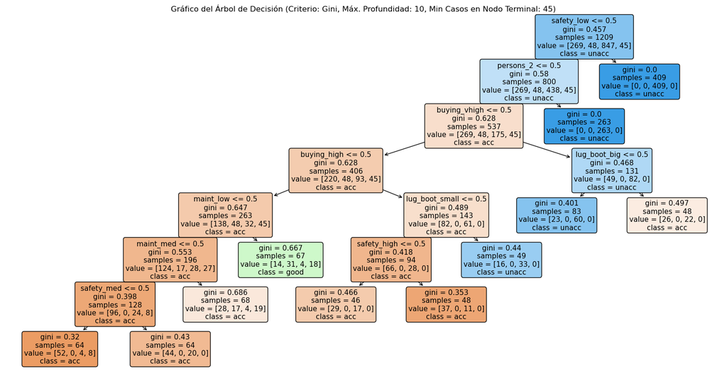

```python
import pandas as pd
from sklearn.model_selection import train_test_split
from sklearn.tree import DecisionTreeClassifier, plot_tree
from sklearn.metrics import confusion_matrix, classification_report
import matplotlib.pyplot as plt

# Dividir en conjuntos de entrenamiento y prueba con muestreo estratificado
train, test = train_test_split(car_evaluation, test_size=0.3, stratify=car_evaluation['class'], random_state=42)

# Separar características (X) y la variable dependiente (y) y codificar variables categóricas
X_train = pd.get_dummies(train.drop('class', axis=1))  # Aplicar pd.get_dummies para codificación
y_train = train['class']
X_test = pd.get_dummies(test.drop('class', axis=1))
y_test = test['class']

# Configuración del modelo de árbol de decisión con restricción de casos mínimos en nodo terminal
model = DecisionTreeClassifier(criterion="gini", max_depth=10, min_samples_split=2, min_samples_leaf=45, random_state=42)

# Entrenar el modelo en el conjunto TRAIN
model.fit(X_train, y_train)

# Función para calcular métricas y generar tablas de clasificación
def calculate_metrics(y_true, y_pred):
    confusion = confusion_matrix(y_true, y_pred, labels=["unacc", "acc", "good", "vgood"])
    tn = confusion[0, 0]
    fp = confusion[0, 1:].sum()
    fn = confusion[1:, 0].sum()
    tp = confusion[1:, 1:].sum()
    total = confusion.sum()
    correct_classification = (tp + tn) / total * 100
    fp_percentage = fp / total * 100
    fn_percentage = fn / total * 100
    return correct_classification, fp_percentage, fn_percentage

# Evaluación en el conjunto TRAIN
y_train_pred = model.predict(X_train)
correct_classification_train, fp_train, fn_train = calculate_metrics(y_train, y_train_pred)

# Evaluación en el conjunto TEST
y_test_pred = model.predict(X_test)
correct_classification_test, fp_test, fn_test = calculate_metrics(y_test, y_test_pred)

# Generar la tabla de evaluación
results = {
    "Conjunto": ["Train", "Test"],
    "Clasificación Correcta (%)": [correct_classification_train, correct_classification_test],
    "Falso Positivo (%)": [fp_train, fp_test],
    "Falso Negativo (%)": [fn_train, fn_test]
}
results_df = pd.DataFrame(results)

# Mostrar la tabla comparativa
print("Tabla Comparativa para el Modelo de Árbol de Decisión (Frecuencia Relativa %):")
print(results_df)

# Imprimir el reporte de clasificación
print("\nReporte de Clasificación para el conjunto TRAIN:\n", classification_report(y_train, y_train_pred))
print("\nReporte de Clasificación para el conjunto TEST:\n", classification_report(y_test, y_test_pred))

# Visualización del árbol de decisión
plt.figure(figsize=(20, 10))
plot_tree(
    model,
    filled=True,
    feature_names=X_train.columns.tolist(),
    class_names=model.classes_.tolist(),
    rounded=True
)
plt.title("Gráfico del Árbol de Decisión (Criterio: Gini, Máx. Profundidad: 10, Min Casos en Nodo Terminal: 45)")
plt.show()
```

## Punto 5: Importancia de predictores

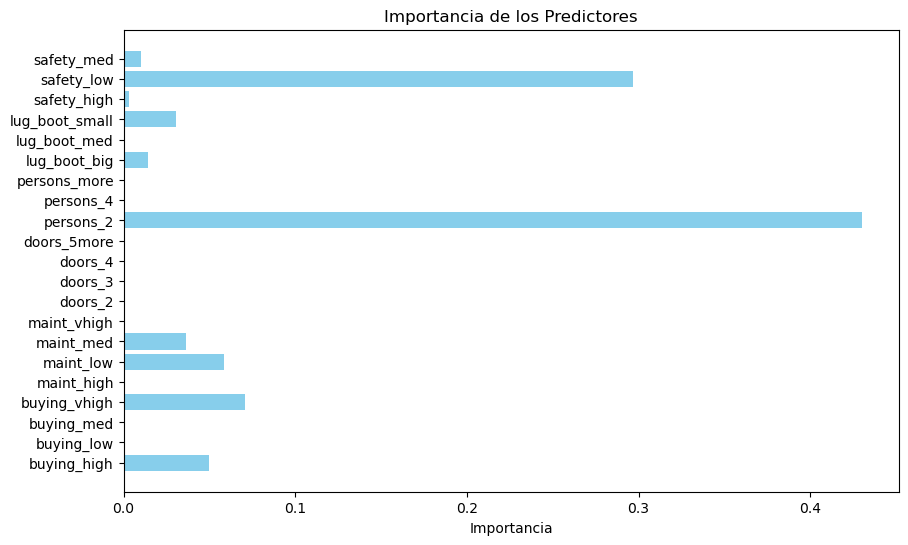

```
Tabla Comparativa para el Modelo de Árbol de Decisión (Frecuencia Relativa %):
  Conjunto  Clasificación Correcta (%)  Falso Positivo (%)  Falso Negativo (%)
0    Train                   89.991729            6.782465            3.225806
1     Test                   88.631985            7.129094            4.238921

Reporte de Clasificación para el conjunto TRAIN:
               precision    recall  f1-score   support

         acc       0.64      0.80      0.71       269
        good       0.46      0.65      0.54        48
       unacc       0.95      0.90      0.93       847
       vgood       0.00      0.00      0.00        45

    accuracy                           0.84      1209
   macro avg       0.51      0.59      0.54      1209
weighted avg       0.83      0.84      0.83      1209


Reporte de Clasificación para el conjunto TEST:
               precision    recall  f1-score   support

         acc       0.61      0.76      0.68       115
        good       0.52      0.71      0.60        21
       unacc       0.94      0.90      0.92       363
       vgood       0.00      0.00      0.00        20

    accuracy                           0.82       519
   macro avg       0.52      0.59      0.55       519
weighted avg       0.81      0.82      0.82       519


Resumen de Nodos Terminales:
    Numero del Nodo                                     Regla del Nodo  \
0                 7   & safety_low <= 0.50 & persons_2 <= 0.50 & bu...
1                 8   & safety_low <= 0.50 & persons_2 <= 0.50 & bu...
2                 9   & safety_low <= 0.50 & persons_2 <= 0.50 & bu...
3                10   & safety_low <= 0.50 & persons_2 <= 0.50 & bu...
4                13   & safety_low <= 0.50 & persons_2 <= 0.50 & bu...
5                14   & safety_low <= 0.50 & persons_2 <= 0.50 & bu...
6                15   & safety_low <= 0.50 & persons_2 <= 0.50 & bu...
7                17   & safety_low <= 0.50 & persons_2 <= 0.50 & bu...
8                18   & safety_low <= 0.50 & persons_2 <= 0.50 & bu...
9                19            & safety_low <= 0.50 & persons_2 > 0.50
10               20                                & safety_low > 0.50

    Casos en el Nodo Categoría Predicha
0                 64                acc
1                 64                acc
2                 68                acc
3                 67               good
4                 46                acc
5                 48                acc
6                 49              unacc
7                 83              unacc
8                 48                acc
9                263              unacc
10               409              unacc
```

[output not shown]

```python
import pandas as pd
import numpy as np
import matplotlib.pyplot as plt
from sklearn.model_selection import train_test_split
from sklearn.tree import DecisionTreeClassifier, plot_tree, export_text
from sklearn.metrics import confusion_matrix, classification_report

# Configuración del modelo de árbol de decisión con restricción de casos mínimos en nodo terminal
model = DecisionTreeClassifier(criterion="gini", max_depth=10, min_samples_split=2, min_samples_leaf=45, random_state=42)

# Entrenar el modelo en el conjunto TRAIN
model.fit(X_train, y_train)

# --- 1. Gráfico de Importancia de las Variables ---
feature_importances = model.feature_importances_
features = X_train.columns

# Crear un gráfico de barras para las importancias de los predictores
plt.figure(figsize=(10, 6))
plt.barh(features, feature_importances, color="skyblue")
plt.xlabel("Importancia")
plt.title("Importancia de los Predictores")
plt.show()

# --- Función para calcular métricas y generar tablas de clasificación ---
def calculate_metrics(y_true, y_pred):
    confusion = confusion_matrix(y_true, y_pred, labels=["unacc", "acc", "good", "vgood"])
    tn = confusion[0, 0]
    fp = confusion[0, 1:].sum()
    fn = confusion[1:, 0].sum()
    tp = confusion[1:, 1:].sum()
    total = confusion.sum()
    correct_classification = (tp + tn) / total * 100
    fp_percentage = fp / total * 100
    fn_percentage = fn / total * 100
    return correct_classification, fp_percentage, fn_percentage

# Evaluación en el conjunto TRAIN
y_train_pred = model.predict(X_train)
correct_classification_train, fp_train, fn_train = calculate_metrics(y_train, y_train_pred)

# Evaluación en el conjunto TEST
y_test_pred = model.predict(X_test)
correct_classification_test, fp_test, fn_test = calculate_metrics(y_test, y_test_pred)

# Generar la tabla de evaluación
results = {
    "Conjunto": ["Train", "Test"],
    "Clasificación Correcta (%)": [correct_classification_train, correct_classification_test],
    "Falso Positivo (%)": [fp_train, fp_test],
    "Falso Negativo (%)": [fn_train, fn_test]
}
results_df = pd.DataFrame(results)

# Mostrar la tabla comparativa
print("Tabla Comparativa para el Modelo de Árbol de Decisión (Frecuencia Relativa %):")
print(results_df)

# Imprimir el reporte de clasificación
print("\nReporte de Clasificación para el conjunto TRAIN:\n", classification_report(y_train, y_train_pred))
print("\nReporte de Clasificación para el conjunto TEST:\n", classification_report(y_test, y_test_pred))

# --- 2. Tabla de Nodos Terminales ---
# Inicializar listas para los detalles de los nodos terminales
node_ids = []
node_rules = []
class_labels = []
case_counts = []

# Función para recorrer los nodos y extraer información de los nodos terminales
def traverse_tree(node, depth=0, rule=""):
    # Verificar si el nodo es terminal
    if model.tree_.children_left[node] == -1 and model.tree_.children_right[node] == -1:
        # Nodo terminal
        node_ids.append(node)
        node_rules.append(rule)

        # Clase más probable en el nodo
        class_counts = model.tree_.value[node][0]
        most_probable_class = model.classes_[np.argmax(class_counts)]
        class_labels.append(most_probable_class)

        # Número de casos en el nodo
        case_counts.append(int(model.tree_.n_node_samples[node]))
    else:
        # Nodo no terminal, construir reglas para hijos
        left_child = model.tree_.children_left[node]
        right_child = model.tree_.children_right[node]

        # Obtenemos el índice de la característica y el umbral de división
        feature = model.tree_.feature[node]
        threshold = model.tree_.threshold[node]

        # Crear regla para el nodo izquierdo
        left_rule = f"{rule} & {features[feature]} <= {threshold:.2f}"
        traverse_tree(left_child, depth + 1, left_rule)

        # Crear regla para el nodo derecho
        right_rule = f"{rule} & {features[feature]} > {threshold:.2f}"
        traverse_tree(right_child, depth + 1, right_rule)

# Llamar a la función para comenzar desde la raíz (nodo 0)
traverse_tree(0)

# Crear un DataFrame con los resultados
node_summary_df = pd.DataFrame({
    "Numero del Nodo": node_ids,
    "Regla del Nodo": node_rules,
    "Casos en el Nodo": case_counts,
    "Categoría Predicha": class_labels
})

# Mostrar la tabla de nodos terminales
print("\nResumen de Nodos Terminales:")
print(node_summary_df)

# Visualización del árbol de decisión
plt.figure(figsize=(20, 10))
plot_tree(
    model,
    filled=True,
    feature_names=features,
    class_names=model.classes_.tolist(),
    rounded=True
)
plt.title("Gráfico del Árbol de Decisión (Criterio: Gini, Máx. Profundidad: 10, Min Casos en Nodo Terminal: 45)")
plt.show()
```

## Conclusiones

Se agrega un algoritmo de parada y en este caso, el arbol se simplifica sin embargo se bajan las capacidades predictivas "clasificación correcta"

1. Train --> 89.991729
2. Test --> 88.631985

El resultado muestra que el orden de importancia de los predictores es:

1. Capacidad del vehiculo en terminos de personas
2. Seguridad
3. Precio de compra
4. Precio de mantenimiento